# U4. Frondizi y el desarrollismo (1958–1962)

Historia Económica Argentina · Clase 19

Sebastian Freille

Universidad Nacional de Córdoba

# Apertura y hoja de ruta

## Dónde quedamos

- La **Revolución Libertadora** (1955) derrocó a Perón e instaló una política económica **ortodoxa** bajo el Plan Prebisch.
- Las elecciones de **1958** llevaron a Arturo Frondizi a la presidencia con apoyo peronista y una promesa de **desarrollo industrial**.
- Hoy analizamos la **estrategia desarrollista**: sus ideas, su implementación y por qué terminó en crisis.

**Idea clave**

Frondizi fue el primer presidente que intentó **industrialización con apertura al capital extranjero**. La tensión entre **desarrollo** y **estabilización** definió su destino.

## La pregunta de hoy

> ¿Qué era el **desarrollismo**? ¿Cómo se implementó en Argentina entre 1958 y 1962? ¿Por qué un programa con **crecimiento industrial** terminó en **devaluación, recesión y caída del gobierno**?

## Mapa de la clase

1. **Bloque 1 — Contexto y estrategia:** de la Revolución Libertadora al diagnóstico desarrollista.
2. **Bloque 2 — El programa de estabilización 1959:** ajuste con el FMI y liberalización.
3. **Bloque 3 — Resultados estructurales:** industria, petróleo y productividad.
4. **Bloque 4 — Tensiones y crisis:** balanza de pagos, salarios y el fin del programa.

# Bloque 1. Contexto y estrategia

## [1.1] El ascenso de Frondizi

- **Revolución Libertadora (1955):** derrocó a Perón; aplicó política ortodoxa bajo el **Plan Prebisch** (1956).
- **Elecciones de 1958:** Frondizi (UCRI) ganó con apoyo **peronista** y una plataforma de desarrollo industrial.
- El nuevo gobierno heredó **inflación crónica**, déficit fiscal y restricción externa.

Gerchunoff y Llach (2007), cap. 6.

## [1.2] ¿Qué es el desarrollismo?

- No fue una **teoría económica**, sino una **estrategia nacional de desarrollo**.
- Dominaba el panorama latinoamericano junto al keynesianismo; era el *mainstream* de los años 40–60.
- Partía de un **diagnóstico pesimista** sobre las exportaciones de productos primarios (tesis Prebisch).

**Postulados centrales**

1. El desarrollo implicaba el paso definitivo de una estructura **agroexportadora** a una **industrial**.
2. Era necesario concentrar inversión en **industrias básicas**, **energía** y **comunicaciones**.
3. El capital extranjero era bienvenido como catalizador del despegue.

Gerchunoff y Llach (2007), cap. 6.

## [1.3] El diagnóstico de Frigerio

- Rogelio Frigerio visualizó a Argentina como **subdesarrollada** “fruto de cien años de colonialismo”.
- El “enemigo”: fuerzas que se oponían a profundos cambios estructurales, beneficiadas por el statu quo agropecuario.
- La política debía priorizar:
  - **Industrias de base** (siderurgia, petroquímica)
  - **Energía** (petróleo, carbón)
  - **Comunicaciones**

Gerchunoff y Llach (2007), cap. 6.

## [1.4] Contexto inflacionario

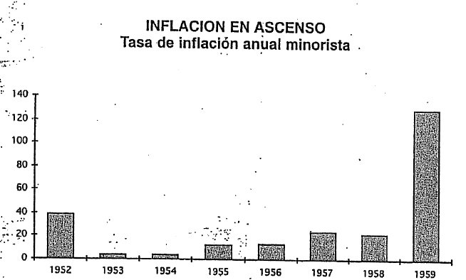

Gerchunoff y Llach (2007), cap. 6.

# Bloque 2. El programa de estabilización 1959

## [2.1] Dos ejes contradictorios

| Eje | Contenido |
| --- | --- |
| **Desarrollista** | Inversión en industrias básicas; Ley de Inversiones Extranjeras; contratos petroleros |
| **Estabilizador** | Ajuste fiscal, monetario y cambiario bajo tutela del **FMI** (1959) |

- Argentina se había incorporado al **FMI y Banco Mundial en 1956**.
- El plan de 1959 incluía los clásicos programas fiscales, monetarios y cambiarios… más una serie de **liberalizaciones** internas y externas.

Gerchunoff y Llach (2007), cap. 6; Eshag y Thorp (1965).

## [2.2] Medidas de estabilización

- **Cambio:** tipo de cambio único y flexible (luego fijo con devaluación incluida); eliminación de controles cambiarios.
- **Fiscal:** reducción del déficit vía impuestos al comercio exterior; contención del gasto corriente.
- **Monetario:** política restrictiva; reducción de redescuentos; tasas de interés más altas.
- **Precios:** eliminación de controles de precios (salvo alquileres); liberación de tarifas de servicios públicos.

**El costo político**

Las primeras medidas de Frondizi habían sido **expansivas** (aumentos salariales, controles). El viraje ajustador de 1959 le costó apoyo popular.

Gerchunoff y Llach (2007), cap. 6.

## [2.3] Política monetaria

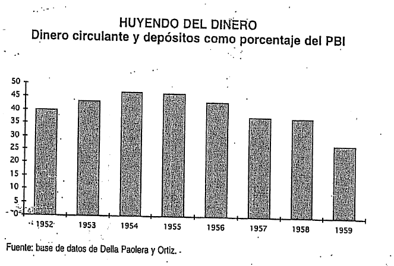

Della Paolera y Ortiz, en Gerchunoff y Llach (2007), cap. 6.

# Bloque 3. Resultados estructurales

## [3.1] Composición industrial

- Gran crecimiento de la **industria automotriz** (también acero y plásticos).
- Las actividades priorizadas crecieron mucho; las tradicionales crecieron poco o menos que la población.
- El desarrollo fue **desparejo**: discontinuidad en la industrialización.

Gerchunoff y Llach (2007), cap. 6.

## [3.2] Industrias preferidas

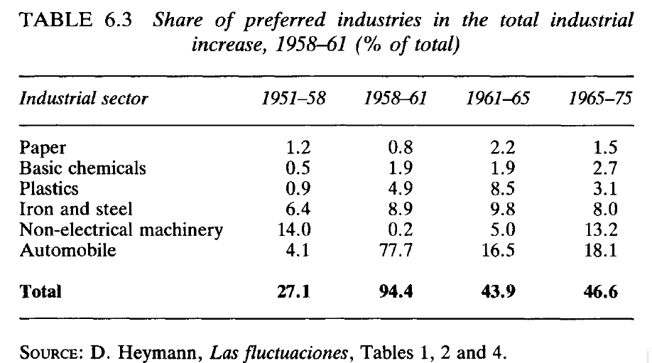

Heymann, *Las fluctuaciones*, en Gerchunoff y Llach (2007), cap. 6.

## [3.3] Productividad

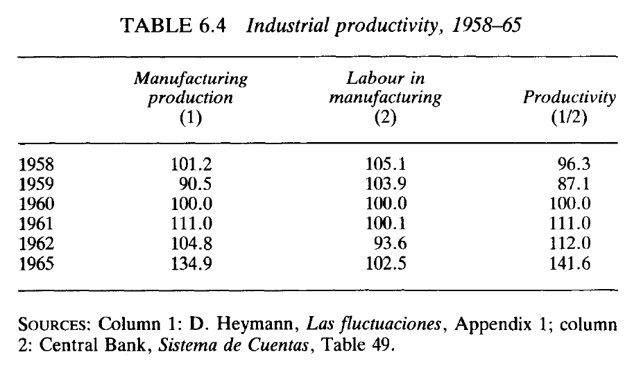

Heymann / BCRA, en Gerchunoff y Llach (2007), cap. 6.

## [3.4] El petróleo

- En 1958 el gobierno anunció **contratos con empresas extranjeras** para extraer petróleo.
- La producción se **triplicó** (de 5,5 a 16 millones de m³); se logró **autoabastecimiento**.
- El escándalo (sin licitación ni aprobación legislativa) le costó el puesto a Frigerio.
- Frondizi perdió **credibilidad y apoyo nacionalista**… pero en lo económico fue una medida exitosa.

**Dilema energético**

El petróleo mostró hasta qué punto Frondizi estaba dispuesto a llevar adelante su programa… y hasta dónde la **política** podía dañar lo **económicamente racional**.

Gerchunoff y Llach (2007), cap. 6.

# Bloque 4. Tensiones y crisis

## [4.1] Balanza de pagos y fiscal

- La balanza de pagos fue el punto más débil: **deficitaria en 1960–62**, salvo en 1959 por efecto devaluatorio.
- Cuenta capital favorable por entrada de IED… pero se revirtió con el deterioro del tipo de cambio real.
- Hacia 1961 la pérdida de reservas anticipaba devaluaciones.

| Año | Saldo comercial (mill. US$) |
| --- | --- |
| 1959 | +150 |
| 1960 | −250 |
| 1961 | −380 |
| 1962 | −180 |

Gerchunoff y Llach (2007), cap. 6.

## [4.2] Salarios reales

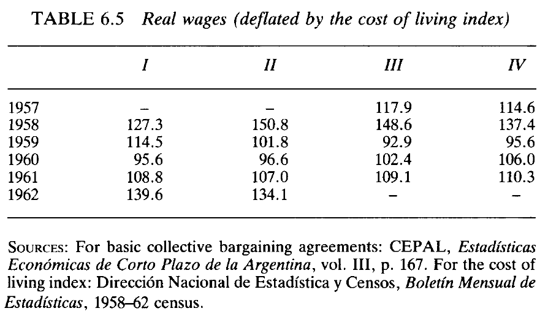

CEPAL / INDEC, en Gerchunoff y Llach (2007), cap. 6.

## [4.3] Precios relativos

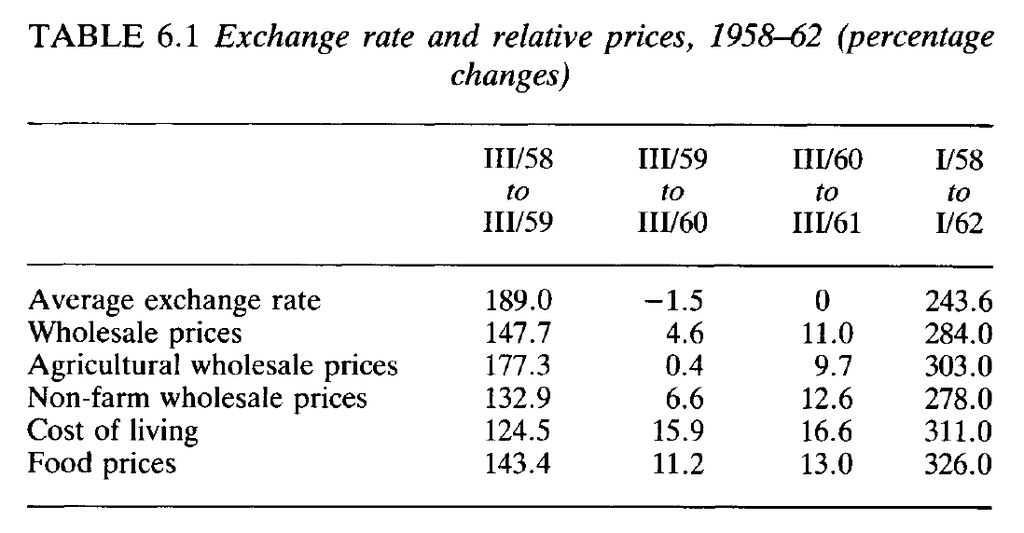

Díaz Alejandro (1970), en Gerchunoff y Llach (2007), cap. 6.

## [4.4] Crisis de 1962

- **1961:** cambio de ministros (Alsogaray → Alemann); rebrote inflacionario por empuje de costos.
- **Conflicto ferroviario:** el gobierno cedió; el BCRA lo financió con **emisión** —el golpe del muerte al plan de estabilización.
- Se cortó el flujo de capital; con tipo de cambio fijo, se fugaron reservas. En **marzo de 1962**: devaluación + caída del gobierno.

**Tensión fatal**

El desarrollismo necesitaba **divisas** para importar bienes de capital… pero el crecimiento industrial aumentaba esas importaciones más rápido que las exportaciones.

Gerchunoff y Llach (2007), cap. 6.

# Cierre

## Ideas fuerza

1. El **desarrollismo** no era una teoría: era una **estrategia de industrialización acelerada** vía inversión extranjera.
2. Frondizi combinó **desarrollo** (industrias básicas, petróleo, Ley de Inversiones) con **estabilización ortodoxa** (FMI, 1959).
3. El crecimiento industrial fue **real pero desparejo**: automotriz y acero crecieron; otras ramas quedaron atrás.
4. La **balanza de pagos** y la **inflación** no se resolvieron; el déficit ferroviario y la emisión del BCRA desataron la crisis.
5. La caída de marzo de 1962 mostró que **desarrollo sin estabilidad externa** era insostenible.

## Preguntas para llevarse

- ¿Era inevitable el **viraje ajustador** de 1959, o Frondizi pudo haber postergado la estabilización?
- ¿El **desarrollismo argentino** fracasó por errores de diseño o por **fragilidad política** (escándalo del petróleo, conflicto ferroviario)?
- ¿Por qué la **industrialización con capital extranjero** generó déficit externo en lugar de solucionarlo?
- ¿Qué lecciones dejó Frondizi para el debate entre **desarrollo vs. estabilización**?

## Bibliografía de la clase

**Obligatoria**

- **Gerchunoff, P. y Llach, L. (2007).** *El ciclo de la ilusión y el desencanto*, **cap. 6**.
- **Eshag, E. y Thorp, R. (1965).** “Las consecuencias económicas y sociales de las políticas ortodoxas aplicadas en la Argentina durante los años de postguerra”.

**Complementaria**

- **Díaz Alejandro, C. (1970).** *Ensayos sobre la historia económica argentina*, caps. 2 y 4.
- **Heymann, D.** *Las fluctuaciones* (cuadros citados en Gerchunoff y Llach, cap. 6).

La bibliografía completa por unidad está en el programa de la asignatura.